# GLM para dados binários

Ana Karolina Silva

## 1 Introdução

Dados binários são caracterizados por variáveis que podem assumir apenas dois estados (0-1), como presença e ausência de espécies ou sobrevivência e morte.

Para exercitar o modelo logístico, usei os dados dos pinguins de Palmer, os mesmos utilizados na aula, que estão armazenados no diretório `/Dados` da disciplina.

```r
#~~~~~~~~~~~~~~~~~~~~~~~~~~~~~~~~
# 1. Importando o banco de dados
#~~~~~~~~~~~~~~~~~~~~~~~~~~~~~~~~
dados <- readRDS("../Dados/palmerpenguins_extended.rds")
```

Visualizando informações contidas no banco de dados:

```r
#~~~~~~~~~~~~~~~~~~~~~~~~~~
# 2. Análise exploratória
#~~~~~~~~~~~~~~~~~~~~~~~~~~
str(dados)
```

```
## 'data.frame':    3430 obs. of  11 variables:
##  $ species          : chr  "Adelie" "Adelie" "Adelie" "Adelie" ...
##  $ island           : chr  "Biscoe" "Biscoe" "Biscoe" "Biscoe" ...
##  $ bill_length_mm   : num  53.4 49.3 55.7 38 60.7 35.7 61 66.1 61.4 54.9 ...
##  $ bill_depth_mm    : num  17.8 18.1 16.6 15.6 17.9 16.8 20.8 20.8 19.9 22.3 ...
##  $ flipper_length_mm: num  219 245 226 221 177 194 211 246 270 230 ...
##  $ body_mass_g      : num  5687 6811 5388 6262 4811 ...
##  $ sex              : chr  "female" "female" "female" "female" ...
##  $ diet             : chr  "fish" "fish" "fish" "fish" ...
##  $ life_stage       : chr  "adult" "adult" "adult" "adult" ...
##  $ health_metrics   : chr  "overweight" "overweight" "overweight" "overweight" ...
##  $ year             : int  2021 2021 2021 2021 2021 2021 2021 2021 2021 2021 ...
```

## 2 Análise exploratória (breve)

### 2.1 Corrigindo os tipos de variáveis

Antes de efetuar a análise exploratória, é importante que cada variável do banco de dados seja caracterizado de acordo com sua natureza (*character*, *factor*, *numeric*, *integer*, etc.).

Olhando a estrutura dos dados, é percebido que precisamos converter as variáveis *character* em *fator*

- Isso permitirá que os níveis do fator possam ser comparados (graficamente e estatisticamente)

```r
# 2.1) Convertendo as variáveis
#~~~~~~~~~~~~~~~~~~~~~~~~~~~~~~~
cols <- c("species", "island", "sex", "diet", "life_stage", "health_metrics", "year")

dados[, cols] <- lapply(dados[, cols], factor)
```

### 2.2 Analisando as métricas de saúde

A coluna `diet` armazena informações sobre as categorias de dietas dos pinguins, destacadas na coluna `diet`.

```r
# 2.2) Explorando os dados
#~~~~~~~~~~~~~~~~~~~~~~~~~~~
table(dados$diet)
```

```
##
##     fish    krill parental    squid
##      958     1419      860      193
```

Ao todo, temos 4 categorias de dieta:

- Fish
- Krill
- Parental
- Squid

Para praticar o modelo logístico, vou considerar apenas as dietas categorizadas como *Fish* ou *Krill*.

Para isso, preciso filtrar os dados para remover os indivíduos que se apresentam outras dietas.

```r
## Filtrando os dados ##
library(dplyr)

dados2 <- filter(dados, !(diet %in% c("parental", "squid")))

dados2 %>%
  group_by(diet) %>%
  summarise(Npinguins = n()) %>%
  mutate(Proporcao = Npinguins / sum(Npinguins))
```

```
## # A tibble: 2 × 3
##   diet  Npinguins Proporcao
##   <fct>     <int>     <dbl>
## 1 fish        958     0.403
## 2 krill      1419     0.597
```

Agora vou avaliar a relação dessas categorias em função de algumas covariáveis inclusas no banco de dados.

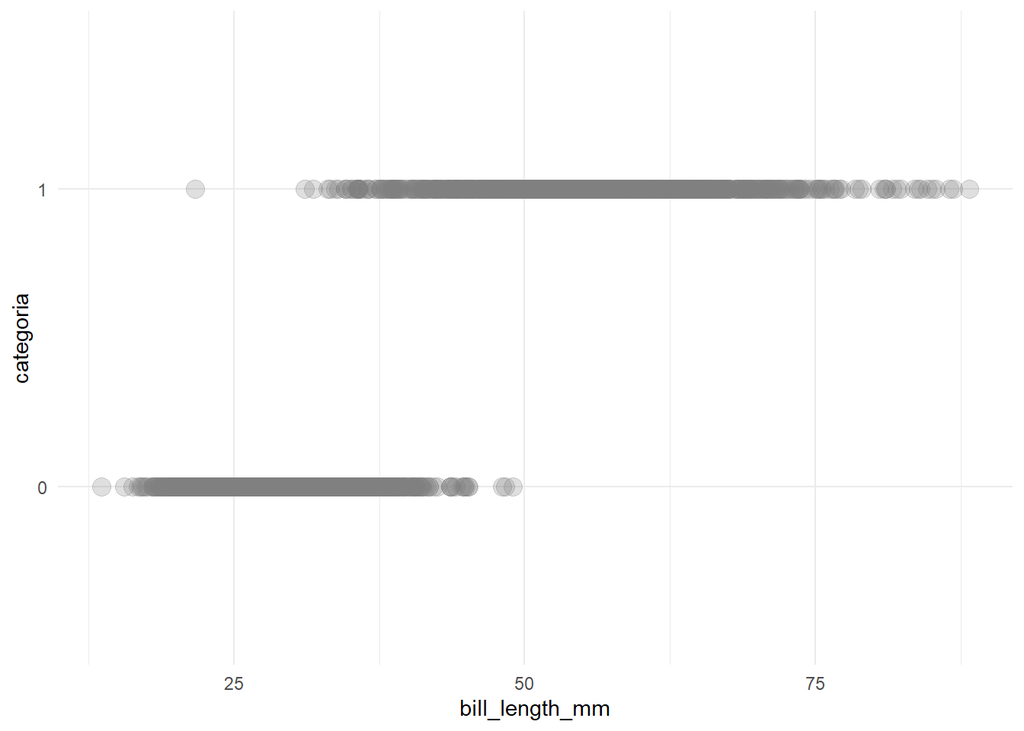

```r
library(ggplot2)
library(dplyr)

## Relação com o tamanho do bico ##
# Precisamos converter as categorias de peso em formato binário

dados2$categoria <- ifelse(dados2$diet == "fish",1, 0) %>% as.factor()

ggplot(dados2, aes(x = bill_length_mm, y = categoria)) +
  geom_point(size = 4, col = 'gray50', alpha = 0.25) +
  theme_minimal()
```

Podemos visualizar que há uma quantidade considerável de pinguins com tamanho de bico maior categorizados na dieta de peixe.

Vamos ver se essa categorização difere quando consideramos a massa corporal:

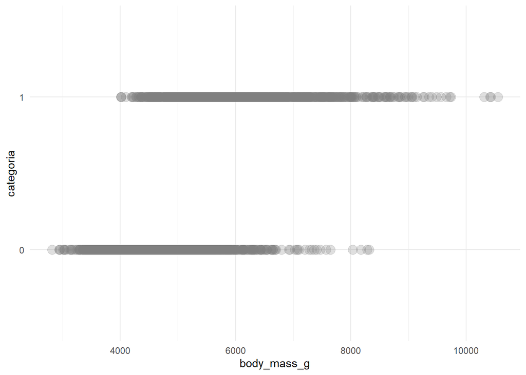

```r
## Incidência de dieta vs. espécie ##
ggplot(dados2, aes(x = body_mass_g, y = categoria)) +
  geom_point(size = 4, col = 'gray50', alpha = 0.25) +
  theme_minimal()
```

Pinguins com peso maior se enquadram na dieta de peixe. Agora, Como ocorre a distribuição das categorias com relação às espécies?

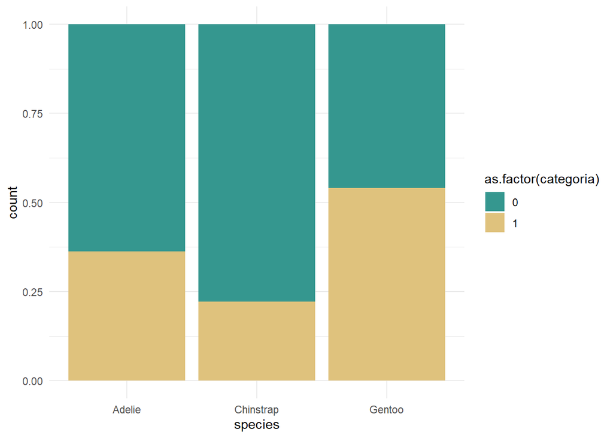

```r
library(ggplot2)
## Incidência de espécie vs dieta ##
ggplot(dados2, aes(x = species, fill = as.factor(categoria))) +
  geom_bar(position = "fill") +
  scale_fill_manual(values = c("#35978f", "#dfc27d"))+
  theme_minimal()
```

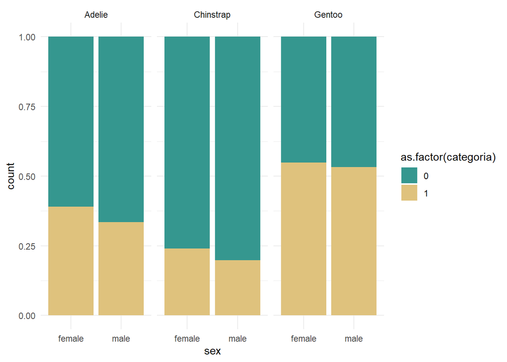

```r
## Incidência de dieta vs. sexo e espécie ##
ggplot(dados2, aes(x = sex, fill = as.factor(categoria))) +
  geom_bar(position = "fill") +
  scale_fill_manual(values = c("#35978f", "#dfc27d"))+
  facet_wrap(species ~ .) +
  theme_minimal()
```

É possível ver que a incidência das dietas difere entre as espécies e levemente entre os sexos e também está relacionada ao comprimento do bico.

## 3 Hipóteses

Com base nessas breves observações, pensei em algumas hipóteses:

- $H_1:$ A dieta baseada em peixe difere entre as espécies;
- $H_2:$ O comprimento do bico influência na dieta;
- $H_3:$ O peso corporal também influencia a dieta;

## 4 Objetivos

Avaliar como a composição da dieta influencia na probabilidade do comprimento do bico e na massa corporal em pinguins do Arquipélago Palmer.

### 4.1 Objetivos específicos

1. **Estimar a influência das espécies na probabilidade da dieta**
   - Permitirá determinar se os pinguins-gentoo, pinguins-de-barbicha e pinguins-de-adélia diferem significativamente na probabilidade de apresentarem bicos maiores devido a dieta.
2. **Avaliar o papel da composição da dieta na probabilidade de bico maior e maior massa corporal**
   - Permitirá avaliar qual item alimentar está associado ao maior tamanho de bico

## 5 Metodologia

Para avaliar se o tamanho do bico e a biomassa corporal influencia a dieta, será utilizado um modelo de regressão logística (i.e., modelo binomial), visto que a variável resposta (*diet*) é binária (Peixe (1) vs. Krill (0)).

Podemos resumir o modelo conforme:

$$y_i \sim Binomial(n_i, p_i)$$

$$logit(p_i) = \eta_i
= \beta_0 +\sum_{j=1}^{J} \beta_j x_{ij}$$

onde $y_i$ é o i*esmo* pinguim, $n_i$ o número total de pinguins, $p_i$ a probabilidade do i*esmo* pinguim consumir peixe, $\beta_0$ o intercepto, $j$ número de covariáveis, $\beta_j$ os coeficientes que quantificam o efeito das covariáveis $x_j$.

Poderíamos escrever o modelo completo, conforme

$$logit(p_i) = \beta_0 + \sum_{j=1}^{J-1}
\beta_j Especie_{i,j} + \sum_{l=1}^{L-1} \nu_l Dieta_{i,l}$$

Usei o método “forward-stepwise”, em que partimos do modelo nulo e inserimos uma covariável por vez.

Os modelos serão comparados pelos valores de AIC e, quando necessário, contrastados (testados) via o *teste de razão de verossimilhança*. Além disso, o ajuste dos modelos será analisado via análises gráficas dos resíduos.

## 6 Análises & Resultados

Iniciaremos as análises montando os modelos, partindo do modelo mais simples (modelo nulo) para o modelo mais complexo (contém todas as covariáveis).

```r
#~~~~~~~~~~~~~~~~~~~~~~
# 3) Testando modelos
#~~~~~~~~~~~~~~~~~~~~~~


## Modelo Nulo
mod0 <- glm(categoria ~ 1,
            family = binomial(link = "logit"),
            data = dados2)

## Modelo 1
mod1 <- glm(categoria ~ body_mass_g,
            family = binomial(link = "logit"),
            data = dados2)

## Modelo 2
mod2 <- glm(categoria ~ bill_length_mm,
            family = binomial(link = "logit"),
            data = dados2)

## Modelo 3
mod3 <- glm(categoria ~ species,
            family = binomial(link = "logit"),
            data = dados2)

## Modelo 4
mod4 <- glm(categoria ~ bill_length_mm +species + body_mass_g,
            family = binomial(link = "logit"),
            data = dados2)
```

Agora que temos alguns modelos, podemos compará-los via valores de AIC

```r
#~~~~~~~~~~~~~~~~~~~~~~~~~~~
# 4) Comparando os modelos
#~~~~~~~~~~~~~~~~~~~~~~~~~~~

## Calcular os valores de AIC ##
aic <- AIC(mod0, mod1, mod2, mod3, mod4)


## Ordenar dos menores aos maiores valores ##
aic %>% arrange(-AIC)
```

```
##      df       AIC
## mod0  1 3207.2454
## mod3  3 3072.3484
## mod1  2 2065.5431
## mod2  2  469.8353
## mod4  5  387.3430
```

De acordo com a tabela, constata-se que o modelo que usou todas as covariávies (mod4) apresentou o melhor ajuste.

Antes de prosseguir, vamos comparar se o modelo 2 e 4 diferem significativamente.

```r
## Teste de razão de verossimilhança ##

#lmtest::lrtest(mod3, mod2) # mesma coisa
anova(mod2, mod4, test = "Chisq")
```

```
## Analysis of Deviance Table
##
## Model 1: categoria ~ bill_length_mm
## Model 2: categoria ~ bill_length_mm + species + body_mass_g
##   Resid. Df Resid. Dev Df Deviance  Pr(>Chi)
## 1      2375     465.84
## 2      2372     377.34  3   88.492 < 2.2e-16 ***
## ---
## Signif. codes:  0 '***' 0.001 '**' 0.01 '*' 0.05 '.' 0.1 ' ' 1
```

Como o p-valor < 0.05, conclui-se que o modelo mais complexo é melhor do que o modelo que não incluiu nem a massa corporal e a espécie como preditoras.

Analisando graficamente o ajuste dos modelo 2 e 4:

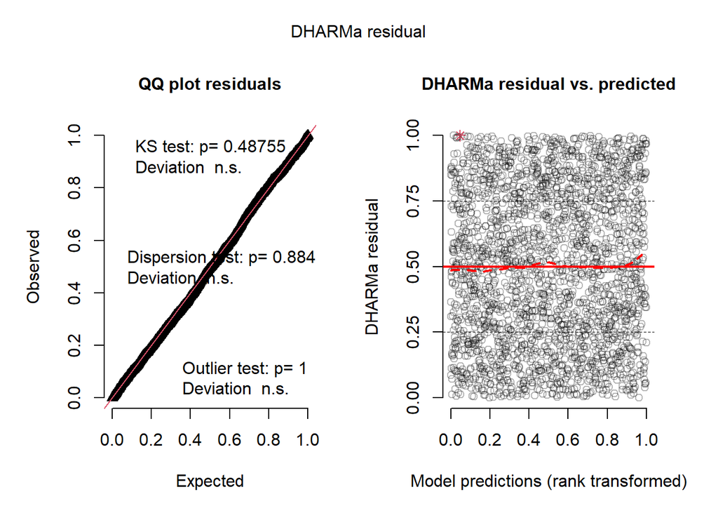

```r
#~~~~~~~~~~~~~~~~~~~~~~~~
# 5) Validação do modelo
#~~~~~~~~~~~~~~~~~~~~~~~~
library(DHARMa)

## Simulando os resíduos a partir do modelo 3 ##
resid_sim <- simulateResiduals(mod2, n=1000)

plot(resid_sim)
```

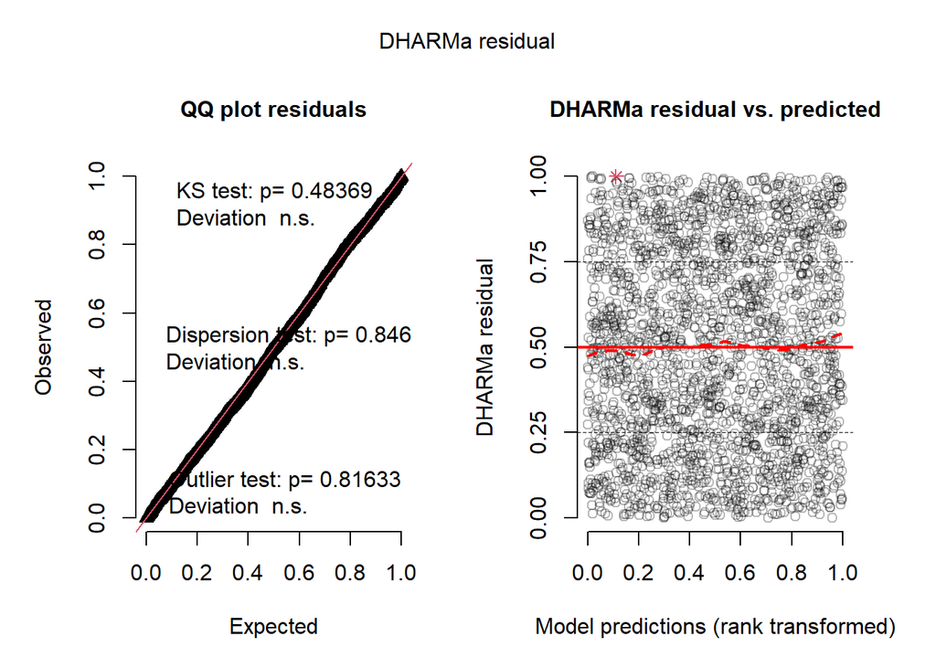

```r
## Simulando os resíduos a partir do modelo 2 ##
resid_sim2 <- simulateResiduals(mod4, n=1000)

plot(resid_sim2)
```

Fazendo uma análise mais minuciosa dos resíduos usando a função `check_model()` do pacote *performance*:

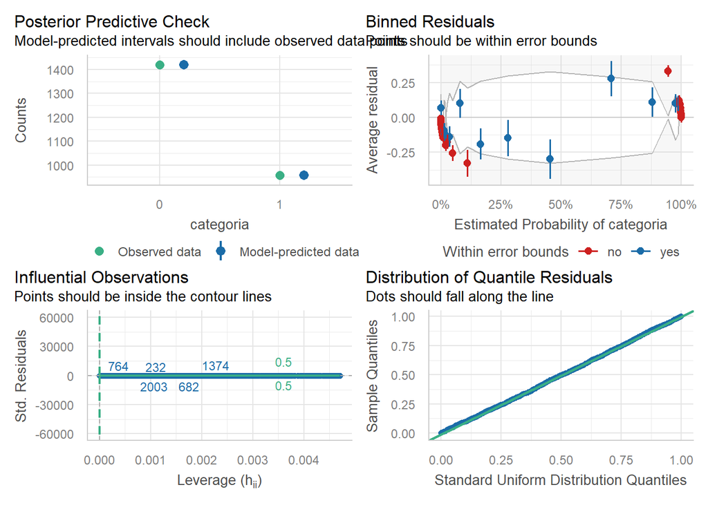

```r
library(performance)

check_model(mod2)
```

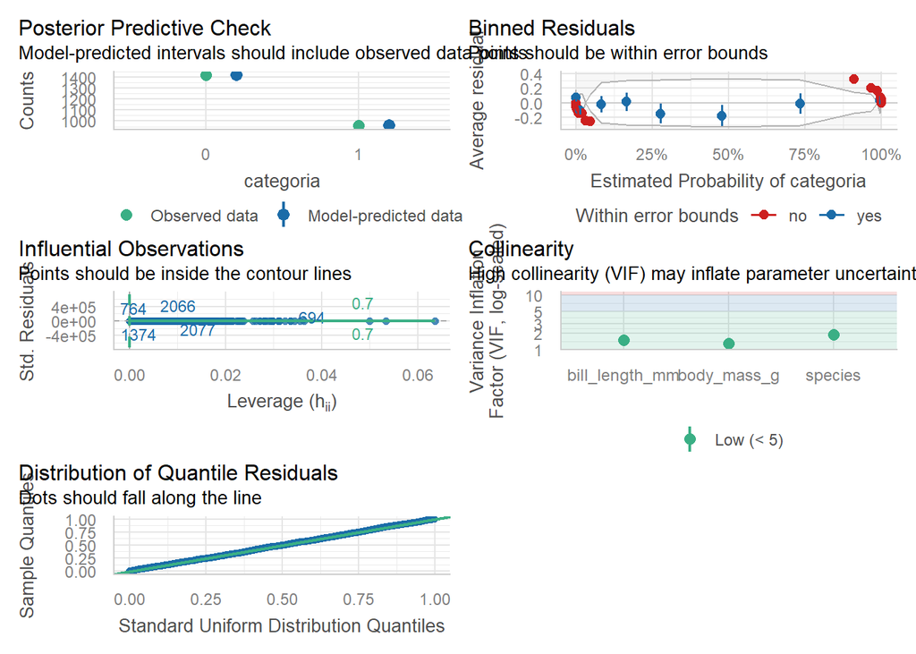

```r
check_model(mod4)
```

Em geral, o modelo está bem ajustado, apesar das falhas nos ‘binned residuals’.

Este último gráfico mostra que nas caudas das probabilidades preditas (próximo de 0% e 100%) o modelo não foi bem calibrado, uma vez que há resíduos fora da banda.

Os resíduos, entretanto, mostram-se muito correlacionados

```r
## Teste de autocorrelação
check_autocorrelation(mod2)
```

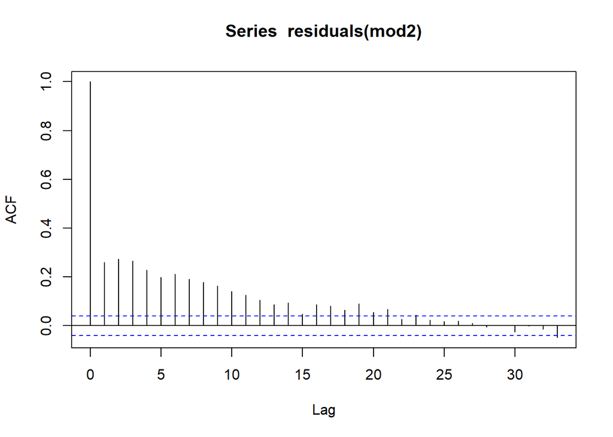

```r
acf(residuals(mod2))
```

```r
check_autocorrelation(mod4)
```

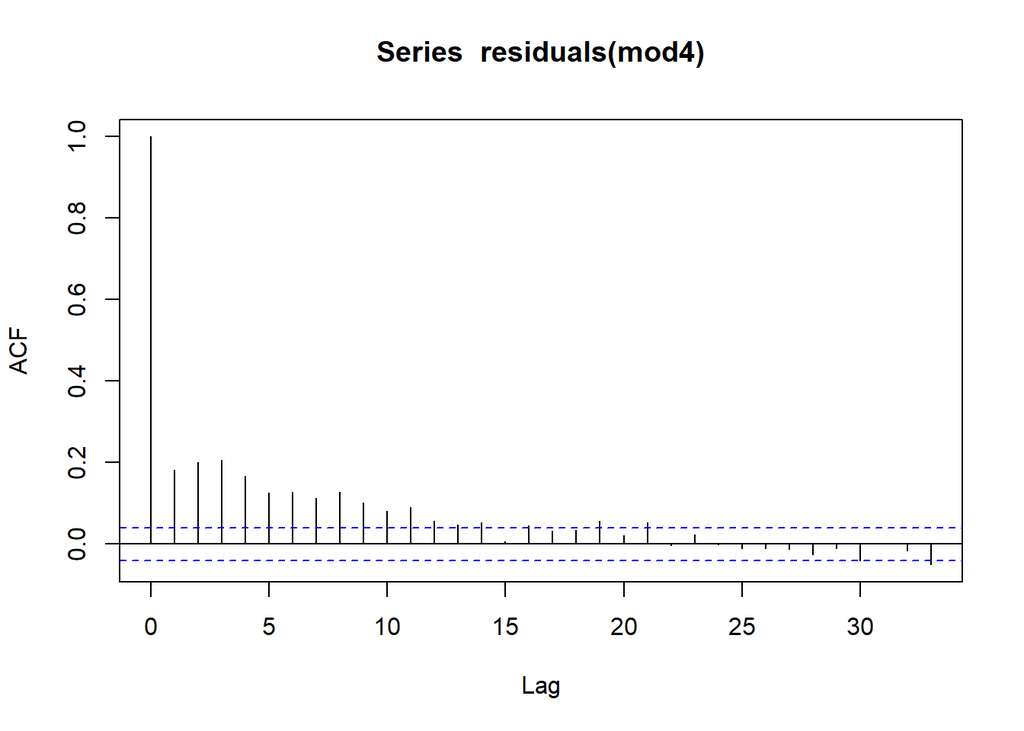

```r
acf(residuals(mod4))
```

Embora, o modelo completo tenha se ajustado aos dados. Houve alta violação da correlação dos residuos.

- Há violação da suposição de independência dos resíduos;
- O modelo pode estar superestimando os efeitos.

Mas seguindo com a análise dos resultados:

```r
#~~~~~~~~~~~~~~~~~~~~~~~~~~~~
# 6) Analisando os resultados
#~~~~~~~~~~~~~~~~~~~~~~~~~~~

summary(mod4)
```

```
##
## Call:
## glm(formula = categoria ~ bill_length_mm + species + body_mass_g,
##     family = binomial(link = "logit"), data = dados2)
##
## Coefficients:
##                    Estimate Std. Error z value Pr(>|z|)
## (Intercept)      -2.474e+01  1.715e+00 -14.430  < 2e-16 ***
## bill_length_mm    5.363e-01  3.644e-02  14.716  < 2e-16 ***
## speciesChinstrap -1.468e+00  3.935e-01  -3.731 0.000191 ***
## speciesGentoo    -3.201e+00  4.160e-01  -7.693 1.43e-14 ***
## body_mass_g       8.554e-04  1.761e-04   4.857 1.19e-06 ***
## ---
## Signif. codes:  0 '***' 0.001 '**' 0.01 '*' 0.05 '.' 0.1 ' ' 1
##
## (Dispersion parameter for binomial family taken to be 1)
##
##     Null deviance: 3205.25  on 2376  degrees of freedom
## Residual deviance:  377.34  on 2372  degrees of freedom
## AIC: 387.34
##
## Number of Fisher Scoring iterations: 9
```

Como estamos trabalhando com uma variável categórica, isso implica que o primeiro nível de cada variável estará absorvido no intercepto. Dessa forma, a interpretação dos resultados é feita de forma relativa.

- i.e., tudo é comparado ao nível de referência
  - Dieta: Krill
  - Espécie: Adelie

Por se tratar de um modelo logístico, todos os parâmetros estão expressos na escala logit e são interpretados sob a forma de *razão de chance*. Esses parâmetros podem ser transformados em probabilidades convertendo-os para escala natural conforme:

$$p = \frac{1}{1 +
exp(-\eta)}$$

- O que podeíamos interpretar dessa tentativa de modelo?

1- Pinguins com bicos mais longos têm maior chance de ter dieta baseada em peixe (coeficiente positivo);

2- Em comparação à espécie de referência (Adelie), Chinstrap tem menor chance de se alimentar de peixe;

3- Gentoo também tem chances menores de se alimentar de peixe do que Adelie;

4- Pinguins mais pesados têm maior chance de dieta baseada em peixe.

## 7 Conclusão

- Esse modelo foi apenas um teste para o relatório, devido a autocorrelação temporal observada, talvez o melhor caminho seria utilizar um modelo alternativo que incluísse a quetão de variação temporal como covariável.